# outlier제거(IQR3기준, 최소화) 및 지역별, 연도별 평단가 분산분석 + 다중회귀분석(종속변수 SalePrice)

## 다중공선성

### LM3모형에 사용한 변수간 상관관계 확인(수치형 변수만)

```r
dataE_N = dataE[,c("SalePrice","Interior","Days","Rooms","Bed","Bath","Condo","Tax","HousePriceIndex")]
```

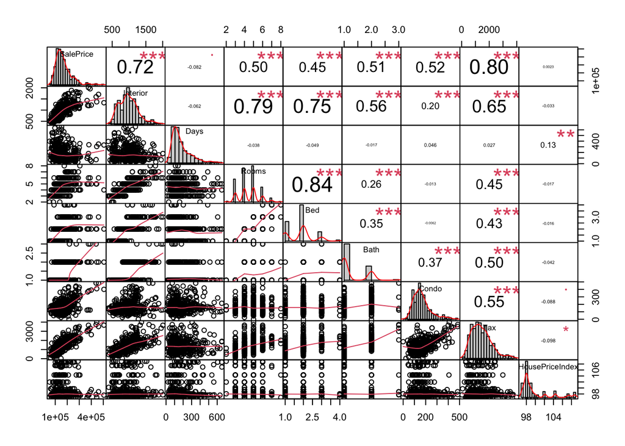

```r
chart.Correlation(dataE_N)
```

Interior - Rooms  
Interior - Bed Interior - Bath  
Interior - Tax Rooms - Bed

위 변수간에 상관관계가 특히 높다.

LM3 다중회귀모형의 회귀계수를 살펴보자.

```r
LM3$coefficients
```

```
       (Intercept)           Interior          Zone2Zone          Zone3Zone
     -2.039081e+05       1.090659e+02       5.867846e+04       5.918198e+04
         Zone4Zone          Zone5Zone    HousePriceIndex               Days
      6.768925e+04      -1.635594e+04       1.890990e+03       8.572502e+01
             Rooms                Bed               Bath              Condo
      1.770454e+04      -5.774531e+04      -8.689075e+03       1.773954e+02
               Tax                RC1      Zone2Zone:Tax      Zone3Zone:Tax
      2.389813e+01      -8.158504e+04      -5.496679e+01      -5.586131e+01
     Zone4Zone:Tax      Zone5Zone:Tax       Interior:Tax            Bed:RC1
     -3.447192e+01      -9.137458e+01       4.979519e-02       2.618259e+04
          Bath:RC1     Interior:Rooms Interior:Zone2Zone Interior:Zone3Zone
      3.336106e+04      -2.137602e+01       4.866893e+01       4.281958e+01
Interior:Zone4Zone Interior:Zone5Zone          Condo:RC1       Interior:RC1
     -6.035993e+00       1.007010e+02      -1.262075e+02       5.732790e+01
    Zone2Zone:Days     Zone3Zone:Days     Zone4Zone:Days     Zone5Zone:Days
     -1.517934e+02      -1.636580e+02      -1.253359e+02      -1.633269e+01
         Rooms:Bed          Rooms:RC1 Interior:Rooms:RC1
      6.484050e+03       7.588509e+03      -1.599104e+01
```

5Zone, 1994년, RC=1 일 경우 Zone의 Reference Group = 1Zone

Days 8.572502e+01 Bed -5.774531e+04 Bath -8.689075e+03 Interior:RC1 5.732790e+01 의 회귀계수 부호 이상함

```r
lm(SalePrice ~ Days,dataE)
```

```
Call:
lm(formula = SalePrice ~ Days, data = dataE)

Coefficients:
(Intercept)         Days
  169158.06       -45.42
```

```r
lm(SalePrice ~ Bed,dataE)
```

```
Call:
lm(formula = SalePrice ~ Bed, data = dataE)

Coefficients:
(Intercept)          Bed
      79699        43369
```

```r
lm(SalePrice ~ Bath,dataE)
```

```
Call:
lm(formula = SalePrice ~ Bath, data = dataE)

Coefficients:
(Intercept)         Bath
      69970        70108
```

```r
lm(SalePrice ~ Bed*RC,dataE)
```

```
Call:
lm(formula = SalePrice ~ Bed * RC, data = dataE)

Coefficients:
(Intercept)          Bed          RC1      Bed:RC1
     119795        31878       -53466        13282
```

```r
lm(SalePrice ~ Bath*RC, dataE)
```

```
Call:
lm(formula = SalePrice ~ Bath * RC, data = dataE)

Coefficients:
(Intercept)         Bath          RC1     Bath:RC1
      75789        64374       -27134        27015
```

```r
lm(SalePrice ~ Interior*RC, dataE)
```

```
Call:
lm(formula = SalePrice ~ Interior * RC, data = dataE)

Coefficients:
 (Intercept)      Interior           RC1  Interior:RC1
    -6904.89        180.06      25376.09        -36.88
```

```r
lm(SalePrice ~ Rooms*RC,dataE)
```

```
Call:
lm(formula = SalePrice ~ Rooms * RC, data = dataE)

Coefficients:
(Intercept)        Rooms          RC1    Rooms:RC1
      50729        29385       -38825         1101
```

```r
F3 # LM3 회귀모형의 분산분석
```

```
Analysis of Variance Table

Response: SalePrice
                   Df     Sum Sq    Mean Sq   F value    Pr(>F)
Interior            1 9.9447e+11 9.9447e+11 1478.5450 < 2.2e-16 ***
Zone                4 1.9977e+11 4.9942e+10   74.2520 < 2.2e-16 ***
HousePriceIndex     1 7.6673e+09 7.6673e+09   11.3994 0.0008083 ***
Days                1 5.1742e+09 5.1742e+09    7.6928 0.0058098 **
Rooms               1 1.3179e+10 1.3179e+10   19.5945 1.244e-05 ***
Bed                 1 5.2292e+09 5.2292e+09    7.7746 0.0055573 **
Bath                1 7.4004e+09 7.4004e+09   11.0026 0.0009950 ***
Condo               1 1.1789e+11 1.1789e+11  175.2770 < 2.2e-16 ***
Tax                 1 1.2035e+11 1.2035e+11  178.9343 < 2.2e-16 ***
RC                  1 1.5163e+10 1.5163e+10   22.5443 2.887e-06 ***
Zone:Tax            4 5.8902e+10 1.4726e+10   21.8934 2.548e-16 ***
Interior:Tax        1 2.2182e+10 2.2182e+10   32.9793 1.873e-08 ***
Bed:RC              1 1.4151e+10 1.4151e+10   21.0393 6.068e-06 ***
Bath:RC             1 5.9837e+09 5.9837e+09    8.8963 0.0030366 **
Interior:Rooms      1 6.7405e+09 6.7405e+09   10.0216 0.0016684 **
Interior:Zone       4 1.0231e+10 2.5576e+09    3.8026 0.0047850 **
Condo:RC            1 6.5623e+09 6.5623e+09    9.7566 0.0019199 **
Interior:RC         1 3.9945e+09 3.9945e+09    5.9388 0.0152561 *
Zone:Days           4 7.8498e+09 1.9625e+09    2.9177 0.0212168 *
Rooms:Bed           1 2.3109e+09 2.3109e+09    3.4358 0.0645519 .
Rooms:RC            1 1.7225e+09 1.7225e+09    2.5610 0.1103384
Interior:Rooms:RC   1 2.8676e+09 2.8676e+09    4.2634 0.0395998 *
Residuals         391 2.6299e+11 6.7260e+08
---
Signif. codes:  0 '***' 0.001 '**' 0.01 '*' 0.05 '.' 0.1 ' ' 1
```

전체적으로 p값이 매우 낮은편

유의하지 않은 회귀계수는

```
Rooms:Bed         0.0645519 .
Rooms:RC          0.1103384
```

```r
vif(LM3)
```

```
there are higher-order terms (interactions) in this model
consider setting type = 'predictor'; see ?vif
```

```
                          GVIF Df GVIF^(1/(2*Df))
Interior          1.493800e+02  1       12.222110
Zone              1.023298e+05  4        4.229122
HousePriceIndex   1.078871e+00  1        1.038687
Days              1.854012e+01  1        4.305824
Rooms             5.793590e+01  1        7.611564
Bed               7.270948e+01  1        8.526985
Bath              4.832917e+00  1        2.198390
Condo             4.894854e+00  1        2.212432
Tax               4.188205e+01  1        6.471634
RC                2.258559e+02  1       15.028503
Zone:Tax          8.225966e+04  4        4.115270
Interior:Tax      4.297632e+01  1        6.555633
Bed:RC            4.657159e+01  1        6.824338
Bath:RC           1.518598e+01  1        3.896919
Interior:Rooms    2.304413e+02  1       15.180295
Interior:Zone     2.017493e+06  4        6.139055
Condo:RC          8.722107e+00  1        2.953321
Interior:RC       3.135192e+02  1       17.706474
Zone:Days         1.653899e+03  4        2.525304
Rooms:Bed         1.277967e+02  1       11.304718
Rooms:RC          3.444865e+02  1       18.560348
Interior:Rooms:RC 3.054829e+02  1       17.478069
```

Interior, Rooms, Bed,Tax, RC, Interior:Tax, Bed:RC, Interior:Rooms ,Interior:RC, Rooms:Bed, Rooms:RC, Interior:Rooms:RC 의 vif가 가장 높은 편

### 먼저 Bed 변수 제거

```r
LM4 =lm(SalePrice ~ Interior + Zone + HousePriceIndex + Days + Rooms + Bath + Condo + Tax + RC + Zone:Tax + Interior:Tax + Bath:RC + Interior:Rooms + Interior:Zone + Condo:RC +
    Interior:RC + Zone:Days + Rooms:RC + Interior:Rooms:RC,dataE)
F4 = anova(LM4)
F4[20,3] # MSE = 700,424,471
```

```
[1] 700424471
```

MSE는 높아진 상태이다.

```r
F4
```

```
Analysis of Variance Table

Response: SalePrice
                   Df     Sum Sq    Mean Sq   F value    Pr(>F)
Interior            1 9.9447e+11 9.9447e+11 1419.8161 < 2.2e-16 ***
Zone                4 1.9977e+11 4.9942e+10   71.3027 < 2.2e-16 ***
HousePriceIndex     1 7.6673e+09 7.6673e+09   10.9467 0.0010240 **
Days                1 5.1742e+09 5.1742e+09    7.3872 0.0068589 **
Rooms               1 1.3179e+10 1.3179e+10   18.8162 1.831e-05 ***
Bath                1 5.8813e+09 5.8813e+09    8.3967 0.0039690 **
Condo               1 1.2206e+11 1.2206e+11  174.2654 < 2.2e-16 ***
Tax                 1 1.1940e+11 1.1940e+11  170.4696 < 2.2e-16 ***
RC                  1 1.6100e+10 1.6100e+10   22.9867 2.316e-06 ***
Zone:Tax            4 5.9978e+10 1.4994e+10   21.4076 5.401e-16 ***
Interior:Tax        1 2.2934e+10 2.2934e+10   32.7428 2.085e-08 ***
Bath:RC             1 1.2815e+10 1.2815e+10   18.2963 2.376e-05 ***
Interior:Rooms      1 7.1737e+09 7.1737e+09   10.2420 0.0014840 **
Interior:Zone       4 1.0257e+10 2.5643e+09    3.6611 0.0060813 **
Condo:RC            1 7.7823e+09 7.7823e+09   11.1108 0.0009395 ***
Interior:RC         1 3.3458e+08 3.3458e+08    0.4777 0.4898825
Zone:Days           4 7.4794e+09 1.8698e+09    2.6696 0.0319425 *
Rooms:RC            1 5.1954e+08 5.1954e+08    0.7417 0.3896264
Interior:Rooms:RC   1 3.8387e+09 3.8387e+09    5.4805 0.0197274 *
Residuals         394 2.7597e+11 7.0042e+08
---
Signif. codes:  0 '***' 0.001 '**' 0.01 '*' 0.05 '.' 0.1 ' ' 1
```

LM4 다중회귀모형의 회귀계수를 살펴보자.

```r
LM4$coefficients
```

```
       (Intercept)           Interior          Zone2Zone          Zone3Zone
     -1.633835e+05       1.386266e+01       4.700894e+04       4.794897e+04
         Zone4Zone          Zone5Zone    HousePriceIndex               Days
      5.703289e+04      -3.179504e+04       1.857297e+03       7.373570e+01
             Rooms               Bath              Condo                Tax
      1.905299e+03      -1.374505e+04       1.920233e+02       3.093957e+01
               RC1      Zone2Zone:Tax      Zone3Zone:Tax      Zone4Zone:Tax
     -9.942330e+04      -5.627364e+01      -5.641389e+01      -3.501728e+01
     Zone5Zone:Tax       Interior:Tax           Bath:RC1     Interior:Rooms
     -1.105046e+02       4.595008e-02       3.777880e+04      -3.855536e+00
Interior:Zone2Zone Interior:Zone3Zone Interior:Zone4Zone Interior:Zone5Zone
      5.566892e+01       4.820907e+01      -5.179435e-02       1.214816e+02
         Condo:RC1       Interior:RC1     Zone2Zone:Days     Zone3Zone:Days
     -1.424596e+02       6.888585e+01      -1.349036e+02      -1.503966e+02
    Zone4Zone:Days     Zone5Zone:Days          Rooms:RC1 Interior:Rooms:RC1
     -1.161251e+02       1.464655e+01       2.146103e+04      -1.763856e+01
```

```r
gvlma(LM4)
```

```
Call:
lm(formula = SalePrice ~ Interior + Zone + HousePriceIndex +
    Days + Rooms + Bath + Condo + Tax + RC + Zone:Tax + Interior:Tax +
    Bath:RC + Interior:Rooms + Interior:Zone + Condo:RC + Interior:RC +
    Zone:Days + Rooms:RC + Interior:Rooms:RC, data = dataE)

Coefficients:
       (Intercept)            Interior           Zone2Zone           Zone3Zone
        -1.634e+05           1.386e+01           4.701e+04           4.795e+04
         Zone4Zone           Zone5Zone     HousePriceIndex                Days
         5.703e+04          -3.180e+04           1.857e+03           7.374e+01
             Rooms                Bath               Condo                 Tax
         1.905e+03          -1.375e+04           1.920e+02           3.094e+01
               RC1       Zone2Zone:Tax       Zone3Zone:Tax       Zone4Zone:Tax
        -9.942e+04          -5.627e+01          -5.641e+01          -3.502e+01
     Zone5Zone:Tax        Interior:Tax            Bath:RC1      Interior:Rooms
        -1.105e+02           4.595e-02           3.778e+04          -3.856e+00
Interior:Zone2Zone  Interior:Zone3Zone  Interior:Zone4Zone  Interior:Zone5Zone
         5.567e+01           4.821e+01          -5.179e-02           1.215e+02
         Condo:RC1        Interior:RC1      Zone2Zone:Days      Zone3Zone:Days
        -1.425e+02           6.889e+01          -1.349e+02          -1.504e+02
    Zone4Zone:Days      Zone5Zone:Days           Rooms:RC1  Interior:Rooms:RC1
        -1.161e+02           1.465e+01           2.146e+04          -1.764e+01


ASSESSMENT OF THE LINEAR MODEL ASSUMPTIONS
USING THE GLOBAL TEST ON 4 DEGREES-OF-FREEDOM:
Level of Significance =  0.05

Call:
 gvlma(x = LM4)

                       Value p-value                   Decision
Global Stat        118.52828  0.0000 Assumptions NOT satisfied!
Skewness             0.51538  0.4728    Assumptions acceptable.
Kurtosis           117.94453  0.0000 Assumptions NOT satisfied!
Link Function        0.04697  0.8284    Assumptions acceptable.
Heteroscedasticity   0.02140  0.8837    Assumptions acceptable.
```

영향점 있을 수 있음.

### 영향점 확인

```r
outliers_inf = abs(rstudent(LM4))>3
cbind(dataE[outliers_inf,],rstud = rstudent(LM3)[outliers_inf])
```

```
    AddressNo AddressName Street Unit Area AreaCode Price1 Price2 SalePrice
57         75   Cambridge    Pky  203    E        5 495000 550000    505000
59         75   Cambridge    Pky E408    E        5 457000 457000    400000
76          6       Canal   Park  607    E        5 279000 289000    274500
97         14      Chaucy     St    5   HS        7 395000 395000    365000
145     River       Court   <NA>  701    K        8 315000 315000    300000
407       218   Thorndike     St 104B    K        8 225000 119000    105000
411       217   Thorndike     St  205    K        8 119000 119000    115000
    YearF MonthF DateF  CloseDate Days Interior Bed Bath Rooms Condo  Tax RC
57   1992     09    19 1993-08-16  331     1330   2    2     4   400 3667  0
59   1993     10    30 1993-12-13   44     1225   2    2     5   390 2629  0
76   1992     10    15 1993-06-15  243     1271   2    2     5   378 1300  0
97   1992     06    26 1992-09-30   96     1427   2    2     5   123 2988  1
145  1993     06    19 1993-10-29  132     1119   2    2     4   319 2209  0
407  1991     02    05 1991-05-21  105     1253   2    2     4   274 2186  0
411  1993     05    15 1993-08-06   83     1158   2    2     5   253 2323  0
       PrPerI BedPerR BathPerR  Zone Quarter HousePriceIndex     rstud
57  379.69925     0.5      0.5 1Zone 1992-3Q           97.60  3.207282
59  326.53061     0.4      0.4 1Zone 1993-4Q           99.45  4.069939
76  215.97168     0.4      0.4 1Zone 1992-4Q           97.82  3.054191
97  255.78136     0.4      0.4 4Zone 1992-2Q           96.83  3.219385
145 268.09651     0.5      0.5 2Zone 1993-2Q           98.06  3.476077
407  83.79888     0.5      0.5 2Zone 1991-1Q           98.75 -5.202929
411  99.30915     0.4      0.4 2Zone 1993-2Q           98.06 -4.268048
```

```r
outliers_inf_index = which(outliers_inf)
```

```r
dataF = dataE[-outliers_inf_index,]
```

```r
leverage = hatvalues(LM4)> 4/426
cbind(dataE[leverage,],hatv = hatvalues(LM3)[leverage]) #전체 데이터 모두 레버리지는 높음.
```

[output not shown]

[output cut: 1266 more lines]

```r
LM4A =lm(SalePrice ~ Interior + Zone + HousePriceIndex + Days + Rooms + Bath + Condo + Tax + RC + Zone:Tax + Interior:Tax + Bath:RC + Interior:Rooms + Interior:Zone + Condo:RC +
    Interior:RC + Zone:Days + Rooms:RC + Interior:Rooms:RC,dataF)
F4A = anova(LM4A)
F4A[20,3] # MSE = 548,253,900
```

```
[1] 548253900
```

```r
F4A
```

```
Analysis of Variance Table

Response: SalePrice
                   Df     Sum Sq    Mean Sq   F value    Pr(>F)
Interior            1 9.1011e+11 9.1011e+11 1660.0149 < 2.2e-16 ***
Zone                4 1.4417e+11 3.6043e+10   65.7416 < 2.2e-16 ***
HousePriceIndex     1 8.4806e+09 8.4806e+09   15.4684 9.941e-05 ***
Days                1 5.7292e+09 5.7292e+09   10.4500 0.0013317 **
Rooms               1 8.9987e+09 8.9987e+09   16.4134 6.155e-05 ***
Bath                1 6.1681e+09 6.1681e+09   11.2504 0.0008747 ***
Condo               1 1.1727e+11 1.1727e+11  213.8984 < 2.2e-16 ***
Tax                 1 9.8786e+10 9.8786e+10  180.1837 < 2.2e-16 ***
RC                  1 9.6654e+09 9.6654e+09   17.6295 3.333e-05 ***
Zone:Tax            4 4.3488e+10 1.0872e+10   19.8304 7.275e-15 ***
Interior:Tax        1 2.3254e+10 2.3254e+10   42.4142 2.298e-10 ***
Bath:RC             1 9.3048e+09 9.3048e+09   16.9717 4.643e-05 ***
Interior:Rooms      1 5.8770e+09 5.8770e+09   10.7194 0.0011556 **
Interior:Zone       4 1.2339e+10 3.0847e+09    5.6263 0.0002068 ***
Condo:RC            1 7.0902e+09 7.0902e+09   12.9323 0.0003648 ***
Interior:RC         1 6.8062e+08 6.8062e+08    1.2414 0.2658858
Zone:Days           4 9.5501e+09 2.3875e+09    4.3548 0.0018631 **
Rooms:RC            1 7.3050e+08 7.3050e+08    1.3324 0.2490897
Interior:Rooms:RC   1 2.5622e+09 2.5622e+09    4.6734 0.0312450 *
Residuals         387 2.1217e+11 5.4825e+08
---
Signif. codes:  0 '***' 0.001 '**' 0.01 '*' 0.05 '.' 0.1 ' ' 1
```

```r
LM4A$coefficients
```

```
       (Intercept)           Interior          Zone2Zone          Zone3Zone
     -1.573840e+05      -1.440442e+01       2.667608e+04       2.870026e+04
         Zone4Zone          Zone5Zone    HousePriceIndex               Days
      3.993917e+04      -4.874373e+04       1.885366e+03       9.890547e+01
             Rooms               Bath              Condo                Tax
      3.856807e+03      -1.323751e+04       1.834801e+02       3.392513e+01
               RC1      Zone2Zone:Tax      Zone3Zone:Tax      Zone4Zone:Tax
     -8.086263e+04      -5.917656e+01      -6.104833e+01      -4.259165e+01
     Zone5Zone:Tax       Interior:Tax           Bath:RC1     Interior:Rooms
     -1.119106e+02       4.724611e-02       3.400721e+04      -5.842293e+00
Interior:Zone2Zone Interior:Zone3Zone Interior:Zone4Zone Interior:Zone5Zone
      9.898637e+01       9.026083e+01       4.115580e+01       1.570266e+02
         Condo:RC1       Interior:RC1     Zone2Zone:Days     Zone3Zone:Days
     -1.312280e+02       4.609656e+01      -1.685658e+02      -1.752263e+02
    Zone4Zone:Days     Zone5Zone:Days          Rooms:RC1 Interior:Rooms:RC1
     -1.348493e+02      -1.371508e+01       1.908302e+04      -1.451937e+01
```

```r
# LM4A 다중회귀 모형의 model selection 단계별 선택법

step2 = stepAIC(LM4A, scope = list(upper = ~ Interior * Zone * HousePriceIndex * Days * Rooms * Bath * Condo * Tax * RC, lower = ~1),direction="both",trace = FALSE )
```

```r
# LM4A 다중회귀 모형의 model selection 단계별 선택법 결과

step2$anova
```

```
Stepwise Model Path
Analysis of Deviance Table

Initial Model:
SalePrice ~ Interior + Zone + HousePriceIndex + Days + Rooms +
    Bath + Condo + Tax + RC + Zone:Tax + Interior:Tax + Bath:RC +
    Interior:Rooms + Interior:Zone + Condo:RC + Interior:RC +
    Zone:Days + Rooms:RC + Interior:Rooms:RC

Final Model:
SalePrice ~ Interior + Zone + HousePriceIndex + Days + Rooms +
    Bath + Condo + Tax + RC + Zone:Tax + Interior:Tax + Bath:RC +
    Interior:Rooms + Interior:Zone + Condo:RC + Zone:Days + Rooms:RC +
    Rooms:Bath + Rooms:Condo + Interior:Zone:Tax + Rooms:Bath:RC

                 Step Df   Deviance Resid. Df   Resid. Dev      AIC
1                                         387 212174259465 8461.934
2        + Rooms:Bath  1 4056730701       386 208117528764 8455.846
3 + Interior:Zone:Tax  4 7154372272       382 200963156492 8449.188
4     + Rooms:Bath:RC  1 2911506801       381 198051649691 8445.074
5 - Interior:Rooms:RC  1  322442813       382 198374092504 8443.755
6       - Interior:RC  1  424340654       383 198798433158 8442.651
7       + Rooms:Condo  1 1071561812       382 197726871346 8442.386
```

```r
LM4AA = lm(SalePrice ~ Interior + Zone + HousePriceIndex + Days + Rooms +
    Bath + Condo + Tax + RC + Zone:Tax + Interior:Tax + Bath:RC +
    Interior:Rooms + Interior:Zone + Condo:RC + Zone:Days + Rooms:RC +
    Rooms:Bath + Rooms:Condo + Interior:Zone:Tax + Rooms:Bath:RC,dataF)
F4AA = anova(LM4AA)
F4AA[22,3] #MSE = 517,609,611
```

```
[1] 517609611
```

```r
LM4AA$coefficients
```

```
           (Intercept)               Interior              Zone2Zone
         -1.035566e+05           6.002912e+01           9.529585e+04
             Zone3Zone              Zone4Zone              Zone5Zone
          1.895826e+04           4.161044e+04          -9.890106e+04
       HousePriceIndex                   Days                  Rooms
          1.784493e+03           1.226643e+02          -6.153878e+03
                  Bath                  Condo                    Tax
         -1.228867e+05           2.959029e+02           3.114218e+01
                   RC1          Zone2Zone:Tax          Zone3Zone:Tax
         -1.459520e+05          -1.046708e+02          -4.694217e+01
         Zone4Zone:Tax          Zone5Zone:Tax           Interior:Tax
         -3.165339e+01          -7.156208e+00           5.082338e-02
              Bath:RC1         Interior:Rooms     Interior:Zone2Zone
          1.133444e+05          -2.610172e+01           3.594136e+01
    Interior:Zone3Zone     Interior:Zone4Zone     Interior:Zone5Zone
          1.117421e+02           5.352351e+01           2.709441e+02
             Condo:RC1         Zone2Zone:Days         Zone3Zone:Days
         -1.148722e+02          -1.840736e+02          -1.953217e+02
        Zone4Zone:Days         Zone5Zone:Days              Rooms:RC1
         -1.632246e+02          -7.081083e+01           3.162234e+04
            Rooms:Bath            Rooms:Condo Interior:Zone2Zone:Tax
          2.534190e+04          -2.498285e+01           4.461473e-02
Interior:Zone3Zone:Tax Interior:Zone4Zone:Tax Interior:Zone5Zone:Tax
         -1.449272e-02          -1.226618e-02          -1.381607e-01
        Rooms:Bath:RC1
         -1.965560e+04
```

```r
LM4AA
```

```
Call:
lm(formula = SalePrice ~ Interior + Zone + HousePriceIndex +
    Days + Rooms + Bath + Condo + Tax + RC + Zone:Tax + Interior:Tax +
    Bath:RC + Interior:Rooms + Interior:Zone + Condo:RC + Zone:Days +
    Rooms:RC + Rooms:Bath + Rooms:Condo + Interior:Zone:Tax +
    Rooms:Bath:RC, data = dataF)

Coefficients:
           (Intercept)                Interior               Zone2Zone
            -1.036e+05               6.003e+01               9.530e+04
             Zone3Zone               Zone4Zone               Zone5Zone
             1.896e+04               4.161e+04              -9.890e+04
       HousePriceIndex                    Days                   Rooms
             1.784e+03               1.227e+02              -6.154e+03
                  Bath                   Condo                     Tax
            -1.229e+05               2.959e+02               3.114e+01
                   RC1           Zone2Zone:Tax           Zone3Zone:Tax
            -1.460e+05              -1.047e+02              -4.694e+01
         Zone4Zone:Tax           Zone5Zone:Tax            Interior:Tax
            -3.165e+01              -7.156e+00               5.082e-02
              Bath:RC1          Interior:Rooms      Interior:Zone2Zone
             1.133e+05              -2.610e+01               3.594e+01
    Interior:Zone3Zone      Interior:Zone4Zone      Interior:Zone5Zone
             1.117e+02               5.352e+01               2.709e+02
             Condo:RC1          Zone2Zone:Days          Zone3Zone:Days
            -1.149e+02              -1.841e+02              -1.953e+02
        Zone4Zone:Days          Zone5Zone:Days               Rooms:RC1
            -1.632e+02              -7.081e+01               3.162e+04
            Rooms:Bath             Rooms:Condo  Interior:Zone2Zone:Tax
             2.534e+04              -2.498e+01               4.461e-02
Interior:Zone3Zone:Tax  Interior:Zone4Zone:Tax  Interior:Zone5Zone:Tax
            -1.449e-02              -1.227e-02              -1.382e-01
        Rooms:Bath:RC1
            -1.966e+04
```